# Ejercicio 5 — Modelo denso-dependiente y conservación

Del ajuste de datos a las simulaciones estocásticas

Author

Carlos Iván Espinosa

Published

24/11/2026

## 1. Objetivo

**Objetivo metodológico:** ajustar un modelo de crecimiento denso-dependiente (logístico discreto) a datos de monitoreo, estimar los parámetros $r_d$, $\alpha$ y $K$, y proyectar la población a futuro.

**Objetivo ecológico:** evaluar la viabilidad de una población bajo distintos escenarios (crecimiento actual, reducción de $K$ por pérdida de hábitat, catástrofes) usando simulaciones estocásticas, y discutir implicaciones para la conservación.

## 2. Contexto

En el bosque seco de Catamayo, una población de *Croton aff. wagneri* (arbusto dominante) ha sido monitoreada durante 12 años. La población muestra un crecimiento que se desacelera a medida que se acerca a un límite, lo que sugiere **denso-dependencia**.

**Pregunta ecológica:** ¿cuál es la capacidad de carga de *Croton* en este sitio? ¿Cómo respondería la población a una reducción de $K$ por cambio climático o pérdida de hábitat?

## 3. Entregable

Un **informe PDF de máximo 3 páginas** + un **script de R comentado**.

**Estructura del informe:**

1. **Introducción** (media página): ¿por qué es importante modelar la denso-dependencia? ¿Qué preguntas de conservación se pueden responder?
2. **Metodología** (media página): ¿cómo estimaron $\alpha$ y $K$? ¿Qué decisiones tomaron?
3. **Resultados** (1 página): tablas con los parámetros estimados, gráficos del ajuste y proyecciones.
4. **Discusión** (1 página): interpretación ecológica. ¿Qué escenarios son más riesgosos? ¿Qué implicaciones tiene para la conservación?
5. **Anexo:** script de R comentado.

**Trabajo:** grupal (3–4 estudiantes). **Peso:** 10 puntos (ver rúbrica al final).

# PARTE 1 — Ejemplo guiado

En esta parte, resolveremos juntos un ejemplo con datos de una población de *Croton* en el sitio “El Limón”. Sigue cada paso y verifica tus cálculos.

## Paso 1. Explorar los datos

Los datos de la población de *Croton* en “El Limón” son:

| Año | $N_t$ | $\lambda_t = N_{t+1}/N_t$ |
| --- | --- | --- |
| 0 | 15 | — |
| 1 | 28 | 1,87 |
| 2 | 48 | 1,71 |
| 3 | 78 | 1,63 |
| 4 | 118 | 1,51 |
| 5 | 160 | 1,36 |
| 6 | 198 | 1,24 |
| 7 | 228 | 1,15 |
| 8 | 250 | 1,10 |
| 9 | 264 | 1,06 |
| 10 | 272 | 1,03 |
| 11 | 276 | 1,01 |

**Observación:** $\lambda_t$ disminuye a medida que $N_t$ aumenta. Eso es evidencia de denso-dependencia negativa.

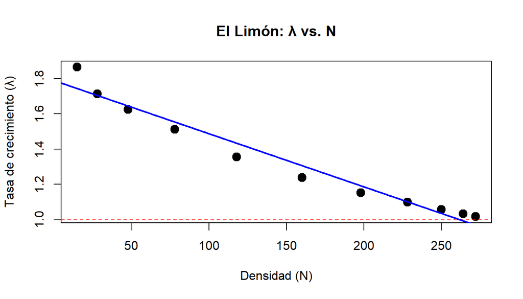

## Paso 2. Ajustar la regresión lineal

Ajustamos una regresión lineal de $\lambda_t$ contra $N_t$:

$$\lambda_t = a + b N_t$$

```
Intercepto (a): 1.7899
```

```
Pendiente (b): -0.003031
```

## Paso 3. Calcular $r_d$, $\alpha$ y $K$

**TipPaso 1 para el estudiante**

## Paso 4. Simular el modelo discreto

$$N_{t+1} = N_t + r_d (1 - \alpha N_t) N_t$$

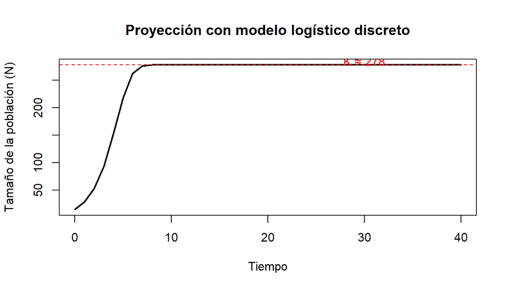

## Paso 5. Simulaciones estocásticas

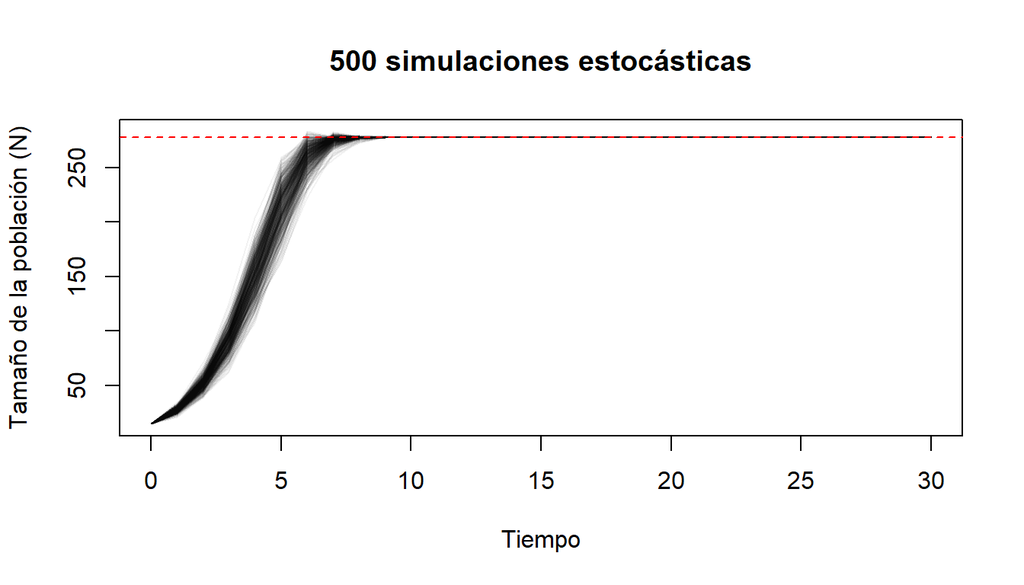

## Paso 6. Preguntas de conservación

**Pregunta 1:** ¿cuál es la probabilidad de que la población caiga por debajo de 50 individuos (umbral crítico) en 30 años?

```
Probabilidad de caer por debajo de 50 individuos: 100 %
```

**Pregunta 2:** ¿qué pasa si $K$ se reduce a 150 por pérdida de hábitat?

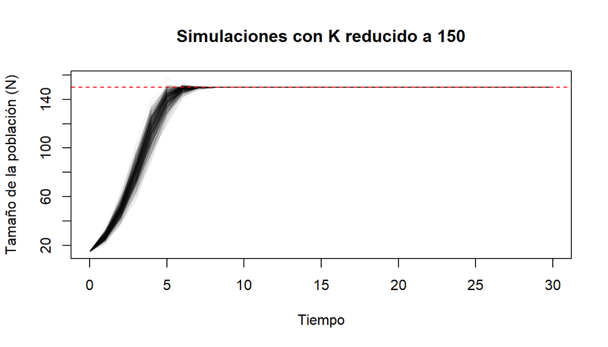

**Pregunta 3:** ¿qué implicaciones tiene esto para la conservación de *Croton* en Catamayo?

# PARTE 2 — Ejercicio autónomo

Ahora te toca a ti. Trabaja con los datos de la población de *Croton* en el sitio “La Quebrada”.

## Datos: La Quebrada

| Año | $N_t$ |
| --- | --- |
| 0 | 20 |
| 1 | 35 |
| 2 | 58 |
| 3 | 90 |
| 4 | 130 |
| 5 | 175 |
| 6 | 220 |
| 7 | 258 |
| 8 | 288 |
| 9 | 310 |
| 10 | 325 |
| 11 | 335 |

## Instrucciones

### Paso 1. Explorar los datos

**A1.** Calcula $\lambda_t$ para cada intervalo. ¿Disminuye con la densidad?

**A2.** Grafica $\lambda_t$ contra $N_t$. ¿Hay evidencia de denso-dependencia?

### Paso 2. Ajustar la regresión

**A3.** Ajusta una regresión lineal de $\lambda_t$ contra $N_t$. Reporta el intercepto ($a$) y la pendiente ($b$).

**A4.** Calcula $r_d$, $\alpha$ y $K$.

### Paso 3. Simular el modelo

**A5.** Simula la población con el modelo discreto, usando $N_0 = 20$ y 30 años. Grafica la trayectoria.

**A6.** ¿La población se estabiliza en $K$? ¿En cuánto tiempo?

### Paso 4. Simulaciones estocásticas

**A7.** Simula 500 trayectorias de 30 años con $r_d \sim N(\bar{r}_d, 0,15)$. Grafica las trayectorias.

**A8.** Calcula la probabilidad de que la población caiga por debajo de 100 individuos en 30 años.

### Paso 5. Preguntas de conservación

**A9.** ¿Qué pasa si $K$ se reduce a 200 por pérdida de hábitat? Simula y compara con el escenario base.

**A10.** ¿Qué pasa si $K$ se reduce a 150? ¿La población persiste?

**A11.** ¿Qué escenario es más riesgoso para la conservación de *Croton* en La Quebrada? ¿Por qué?

**A12.** Si tuvieras que recomendar un plan de manejo para esta población, ¿qué acciones propondrías? Menciona al menos dos, basadas en tus resultados.

### Paso 6. Reflexión

**A13.** ¿Qué limitaciones tiene este análisis? Menciona al menos tres.

**A14.** ¿Cómo podrías mejorar el modelo para que sea más realista? Menciona al menos dos mejoras.

# Rúbrica de evaluación

**Total: 10 puntos.**

| Criterio | Excelente (2 pts) | Aceptable (1 pt) | Insuficiente (0 pts) | Puntos |
| --- | --- | --- | --- | --- |
| **Exploración y ajuste (Pasos 1–2)** | Calcula correctamente $\lambda_t$, ajusta la regresión y obtiene $r_d$, $\alpha$ y $K$. | Calcula con errores menores. | No calcula o comete errores graves. | /2 |
| **Simulación del modelo (Paso 3)** | Simula correctamente, grafica y verifica que la población se estabiliza en $K$. | Simula con errores menores. | No simula o no verifica. | /2 |
| **Simulaciones estocásticas (Paso 4)** | Simula 500 trayectorias, calcula la probabilidad de caer bajo el umbral y grafica. | Simula con errores menores. | No simula o no calcula. | /2 |
| **Preguntas de conservación (Paso 5)** | Responde correctamente las preguntas, compara escenarios y propone acciones de manejo. | Responde parcialmente o sin profundidad. | No responde o responde mal. | /2 |
| **Reflexión y limitaciones (Paso 6)** | Plantea limitaciones bien fundamentadas y propone mejoras concretas. | Menciona limitaciones sin profundizar. | No reflexiona. | /1 |
| **Script de R** | Script comentado, reproducible y bien organizado. | Script funcional pero poco comentado. | Script no funcional o ausente. | /1 |
| **TOTAL** |  |  |  | **/10** |

# Clave de respuestas (solo para el docente)

**NoteNo publicar esta sección**

Esta clave es solo para el docente. En la versión del estudiante, eliminarla.

## La Quebrada — Resultados esperados

**Paso 1:** - $\lambda_t$: 1,75; 1,66; 1,55; 1,44; 1,35; 1,26; 1,17; 1,12; 1,08; 1,05; 1,03.

**Paso 2:** - Regresión: $\lambda_t \approx 1,80 - 0,0023 N_t$. - $r_d = 0,80$; $\alpha = 0,0023 / 0,80 = 0,0029$; $K = 1/0,0029 \approx 345$.

**Paso 3:** - La población se estabiliza en $K \approx 345$ en unos 25–30 años.

**Paso 4:** - Probabilidad de caer por debajo de 100: baja (~5–10%).

**Paso 5:** - Con $K = 200$: la población se estabiliza en 200, pero tarda más en llegar. - Con $K = 150$: la población se estabiliza en 150, pero la probabilidad de caer por debajo de 100 aumenta. - El escenario más riesgoso es $K = 150$, porque la población queda cerca del umbral crítico.

**Paso 6:** - Limitaciones: modelo simple, sin estocasticidad en $K$, sin estructura de edades, sin inmigración/emigración. - Mejoras: incluir variación en $K$, incluir efecto Allee, incluir estructura de edades.

# Instrucciones para el docente

## Antes del ejercicio

1. **Publicar en Canvas** la versión del estudiante (sin la clave de respuestas).
2. **Asegurarse** de que los estudiantes tengan acceso a R y a las lecturas 2.4.
3. **Revisar** que los datos de La Quebrada estén completos.

## Durante el ejercicio

- **Tiempo:** 2 sesiones de 90 minutos (o una sesión de 3 horas).
- **Supervisión:** circular por el aula y resolver dudas.

## Después del ejercicio

1. **Calificar** con la rúbrica.
2. **Devolver** con retroalimentación en un plazo de 7 días.
3. **Revisar** en clase los resultados de La Quebrada y discutir las diferencias entre escenarios.

## Sobre la dificultad

- La Parte 1 es guiada y sirve para que los estudiantes entiendan el flujo.
- La Parte 2 es autónoma y evalúa si pueden aplicar lo aprendido.
- La Parte 2 es la que se califica con la rúbrica.

## Sobre los datos

- Los datos de El Limón y La Quebrada son sintéticos, pero calibrados a los patrones de *Croton* en Catamayo.
- Si quieres, puedo generar más sitios o más años para ampliar el ejercicio.